# lab 8

Riyesh Nath, and Jason Seda

2025-11-14

*In this assignment, we attempt to see what parameters we can use to find if a given male household head is 10 years or older than his female partner.*

*We first examine whether couple type (interracial vs. same-race) and race are associated with the proportion of women married to men more than 10 years older. Examined plots below indicate that certain groups have higher proportion of women married to men who are 10 years or older.*

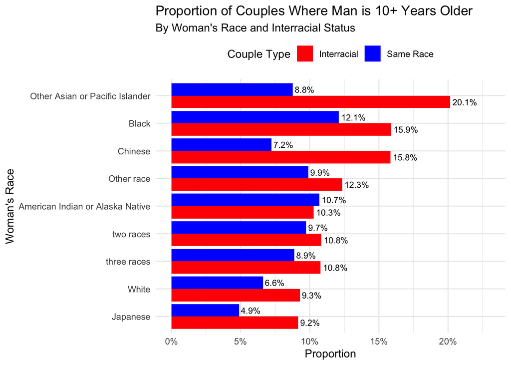

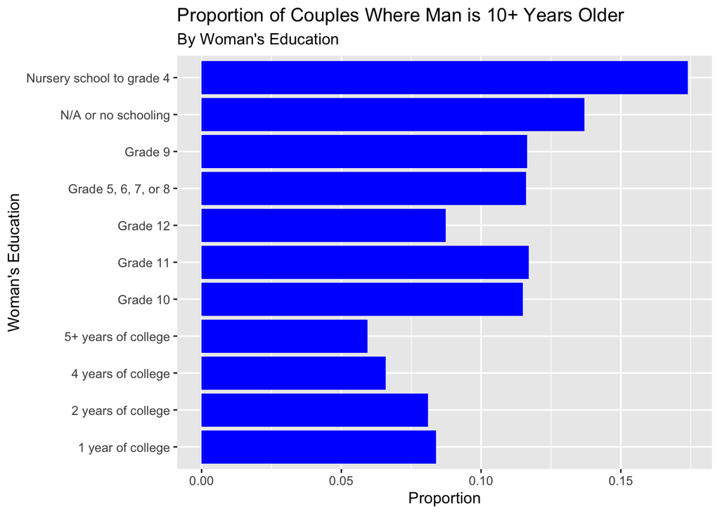

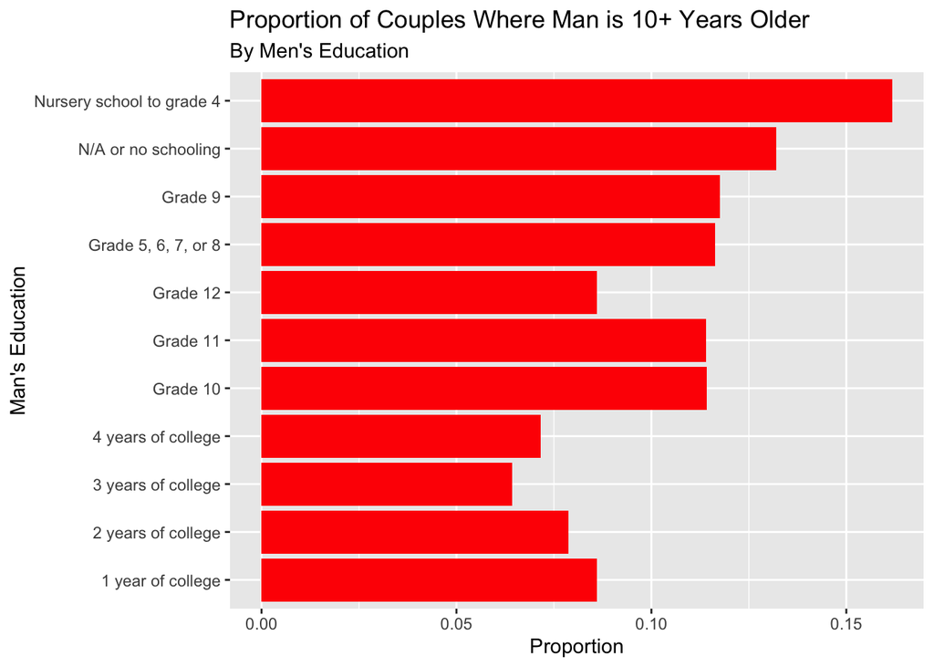

*We also look at the proportion of those born in the US state against those not born in the US state.The graph indicates that a higher proportion of those not born in the US state have 10 years age gap between men and women. However, here the proportion for both are still very low.*

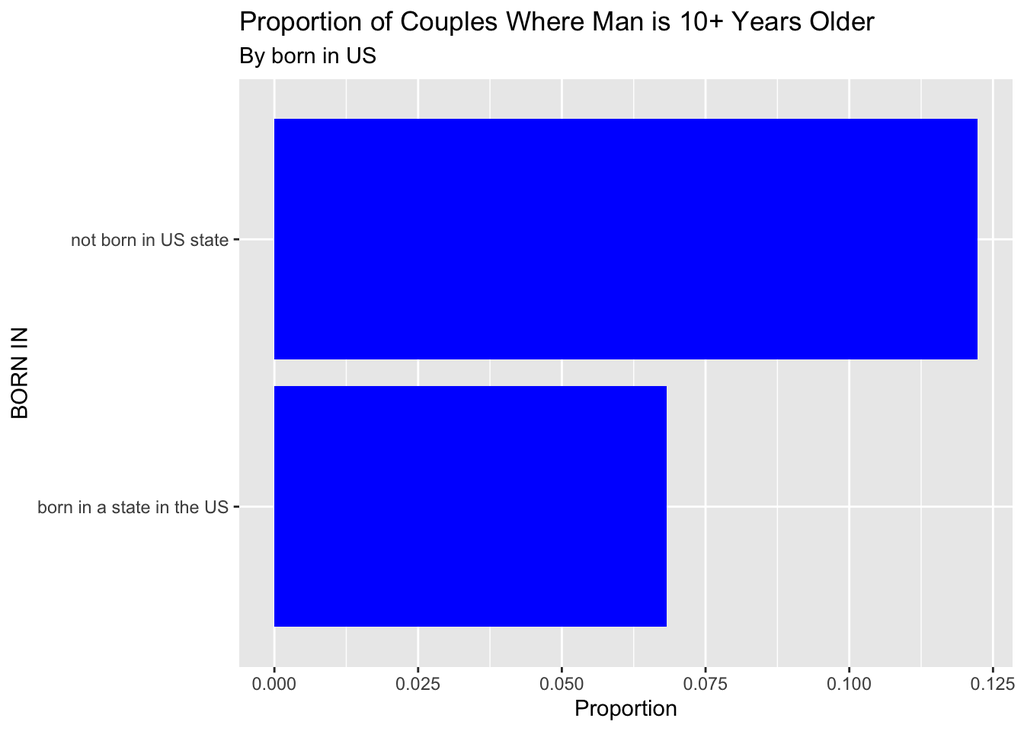

*We also see that different states may have an affect on the proportions of women married to men. Though, as we see with all the charts above, the overall proportion is still very low.*

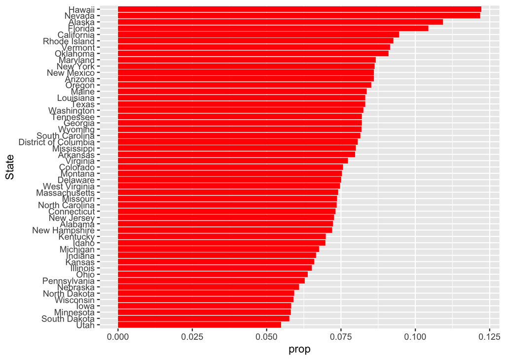

*The overall low proportion trend we see in all the graphs above may be attributed to overall low percent of men who have married women 10 years or younger.*

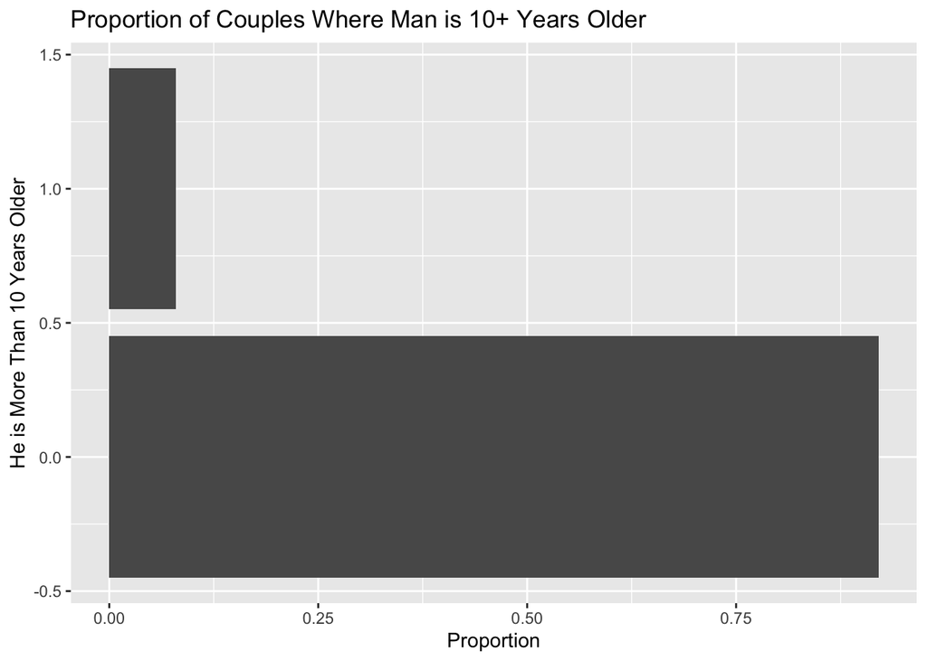

```
##    threshold
## 1 0.08011561
```

```
##
## Call:
## glm(formula = he_more_than_10yrs_than_her ~ same_race + RACE +
##     h_race + EDUC + STATEFIP, family = binomial, data = trad_data)
##
## Coefficients:
##                                         Estimate Std. Error z value Pr(>|z|)
## (Intercept)                            -1.824771   0.064081 -28.476  < 2e-16
## same_race                              -0.380026   0.018079 -21.020  < 2e-16
## RACEBlack                               0.413198   0.041159  10.039  < 2e-16
## RACEAmerican Indian or Alaska Native    0.116098   0.062569   1.856 0.063521
## RACEChinese                             0.697289   0.055675  12.524  < 2e-16
## RACEJapanese                           -0.012198   0.090543  -0.135 0.892837
## RACEOther Asian or Pacific Islander     0.839300   0.032758  25.621  < 2e-16
## RACEOther race                          0.234575   0.037425   6.268 3.66e-10
## RACEtwo races                           0.210466   0.023572   8.929  < 2e-16
## RACEthree races                         0.205267   0.080824   2.540 0.011095
## h_raceBlack                             0.199137   0.039581   5.031 4.88e-07
## h_raceAmerican Indian or Alaska Native  0.047707   0.064169   0.743 0.457207
## h_raceChinese                          -0.624120   0.066097  -9.443  < 2e-16
## h_raceJapanese                         -0.337639   0.119450  -2.827 0.004704
## h_raceOther Asian or Pacific Islander  -0.512169   0.037967 -13.490  < 2e-16
## h_raceOther race                       -0.104633   0.039673  -2.637 0.008354
## h_racetwo races                        -0.090637   0.023551  -3.849 0.000119
## h_racethree races                      -0.349797   0.088308  -3.961 7.46e-05
## EDUCNursery school to grade 4           0.294381   0.072115   4.082 4.46e-05
## EDUCGrade 5, 6, 7, or 8                -0.124466   0.050472  -2.466 0.013663
## EDUCGrade 9                            -0.107385   0.065239  -1.646 0.099760
## EDUCGrade 10                           -0.124283   0.061196  -2.031 0.042264
## EDUCGrade 11                           -0.109382   0.059192  -1.848 0.064616
## EDUCGrade 12                           -0.394270   0.036882 -10.690  < 2e-16
## EDUC1 year of college                  -0.466669   0.039461 -11.826  < 2e-16
## EDUC2 years of college                 -0.481604   0.040284 -11.955  < 2e-16
## EDUC4 years of college                 -0.737469   0.038044 -19.385  < 2e-16
## EDUC5+ years of college                -0.858901   0.039525 -21.731  < 2e-16
## STATEFIPAlaska                          0.403022   0.129868   3.103 0.001914
## STATEFIPArizona                         0.176937   0.062147   2.847 0.004412
## STATEFIPArkansas                        0.095350   0.078416   1.216 0.224004
## STATEFIPCalifornia                      0.210989   0.052498   4.019 5.85e-05
## STATEFIPColorado                        0.125403   0.065926   1.902 0.057148
```

[output cut: 119 more lines]

```
## STATEFIPVirginia
## STATEFIPWashington                     *
## STATEFIPWest Virginia
## STATEFIPWisconsin                      .
## STATEFIPWyoming
## ---
## Signif. codes:  0 '***' 0.001 '**' 0.01 '*' 0.05 '.' 0.1 ' ' 1
##
## (Dispersion parameter for binomial family taken to be 1)
##
##     Null deviance: 229160  on 412274  degrees of freedom
## Residual deviance: 224194  on 412197  degrees of freedom
## AIC: 224350
##
## Number of Fisher Scoring iterations: 5
```

```
## Area under the curve: 0.6071
```

```
##
## pred      0      1
##    0 250679  16594
##    1 128757  16245
```